# Tidybiology Final Project: HARs & WNTs

Missy Lollis

2022-11-03

### I used the following packages to complete this project:

```r
library(tidybiology)
library(dplyr)
library(tidyverse)
library(readxl)
library(knitr)
library(forcats)
library(paletteer)
```

### **Project Goal: To identify differentially expressed genes encoding WNT Pathway Members in *hsHARE5* mouse cortices as compared to wildtype mouse cortices**

### Premise

Human Accelerated Regions (HARs) are genomic regions in that have accelerated rates of mutations in humans despite high conservation in non-human primates. These HARs allow us to study how small genomic changes have influenced human evolution.

The Silver Lab studies HARs in the context of cerebral corticogenesis. We have studied one HAR in particular: *HARE5*, which acts as an enhancer of *FZD8* gene expression. While we have made many important discoveries of the function of HARE5 in human corticogenesis, **I am interested in how multiple HARs have modulated human cortical development**. HARE5 target, FZD8, is part of the important WNT signaling pathway.

**My thesis project is focused on understanding the modulation of WNT signaling during cortical development through synergestic effects of multiple HARs regulating WNT pathway genes.**

For our HARE5 studies, we have generated knock-in mice with *hsHARE5* replacing the mouse loci. scRNA-seq has been performed comparing the *hsHARE5* mouse cortex and the wildtype mouse cortex at E14.5. This work has allowed us to observe important differentially expressed genes. I will be using some of the data to identify differentially expressed WNT pathway genes in *hsHARE5* mouse brains that may also be regulated by HARs.

## Welcome to the Data

I have loaded 4 Datasets:

1. **hare5_top30lfc_markers**
   - Single cell data from RNAseq, contains the top 30 DE genes for each of the clusters that have been created from the data
2. **WNT_Canonical**
   - A list of canonical WNT pathway members
3. **WNT_Noncanonical**
   - A list of non-canonical WNT pathway members
4. **WNT_HAR**
   - A list of WNT pathway members that interact with HARs

## Glimpse of Single Cell Datasets

```r
glimpse(hare5_top30lfc_markers)
```

```
## Rows: 540
## Columns: 10
## $ ...1        <dbl> 1, 2, 3, 4, 5, 6, 7, 8, 9, 10, 11, 12, 13, 14, 15, 16, 17,…
## $ p_val       <dbl> 1.64e-302, 4.87e-213, 2.21e-180, 3.46e-170, 8.89e-164, 1.2…
## $ avg_log2FC  <dbl> 1.2464030, 1.3990864, 1.1120092, 1.2503927, 1.1835842, 0.9…
## $ pct.1       <dbl> 0.709, 1.000, 0.927, 0.880, 0.869, 1.000, 0.929, 1.000, 0.…
## $ pct.2       <dbl> 0.121, 0.728, 0.512, 0.470, 0.484, 0.942, 0.518, 0.899, 0.…
## $ p_val_adj   <dbl> 2.81e-298, 8.35e-209, 3.79e-176, 5.93e-166, 1.52e-159, 2.0…
## $ cluster     <dbl> 0, 0, 0, 0, 0, 0, 0, 0, 0, 0, 0, 0, 0, 0, 0, 0, 0, 0, 0, 0…
## $ gene        <chr> "ENSMUSG00000029591", "ENSMUSG00000021379", "ENSMUSG000000…
## $ SYMBOL...9  <chr> "Ung", "Id4", "Cdca7", "Mcm3", "Mcm6", "Dbi", "Hes5", "Ccn…
## $ SYMBOL...10 <chr> "UNG", "ID4", "CDCA7", "MCM3", "MCM6", "DBI", "HES5", "CCN…
```

This dataset contains 10 variables and 540 observations. I am able to observe the fold change of expression for each gene; however, I am not able to gain any information about specific WNT pathway genes. This is why the additional datasets are important

```r
glimpse(WNT_Canonical)
```

```
## Rows: 75
## Columns: 7
## $ SYMBOL                         <chr> "WNT1", "WNT2", "WNT2B", "WNT3", "WNT3A…
## $ WntPathwayMembers              <chr> "Wnt1", "Wnt2", "Wnt2b", "Wnt3", "Wnt3a…
## $ `Role in WNT Pathway`          <chr> "Ligand", "Ligand", "Ligand", "Ligand",…
## $ Name                           <chr> NA, NA, NA, NA, NA, NA, NA, NA, NA, NA,…
## $ `Human Genome Coordinates...5` <chr> "12.12 (48978322..48982620)", "7.14 (11…
## $ `Human Genome Coordinates...6` <chr> "Chr12:48978322-48982620", "Chr7:117275…
## $ Enhancer                       <lgl> NA, NA, NA, NA, NA, NA, NA, NA, NA, NA,…
```

```r
glimpse(WNT_HAR)
```

```
## Rows: 110
## Columns: 7
## $ SYMBOL                         <chr> "DVL1", "ICAT", "ROR1", "WNT3A", "FZD8"…
## $ WntPathwayMembers              <chr> "DVL1", "ICAT", "ROR1", "Wnt3a", "Fzd8"…
## $ `Role in WNT Pathway`          <chr> "wnt transduction", "negative regulator…
## $ Name                           <chr> "Dishevelled", "catenin beta interactin…
## $ `Human Genome Coordinates...5` <chr> "1.11 (1335278..1349418, complement)", …
## $ `Human Genome Coordinates...6` <chr> "Chr1:1335278-1349418, complement", "Ch…
## $ Enhancer                       <chr> "HARsv2_0002", "HARsv2_0009", "HARsv2_0…
```

```r
glimpse(WNT_Noncanonical)
```

```
## Rows: 42
## Columns: 7
## $ SYMBOL                         <chr> "RHOA", "PRC1", "JNK", "RAC1", "VANGL1"…
## $ WntPathwayMembers              <chr> "RhoA", "PRC1", "JNK", "Rac1", "Vangl1"…
## $ `Role in WNT Pathway`          <chr> "mediator of the noncanonical Wnt/plana…
## $ Name                           <chr> "ras homolog family member A", "protein…
## $ `Human Genome Coordinates...5` <chr> "3.12 (49359145..49411976, complement)"…
## $ `Human Genome Coordinates...6` <chr> "Chr3:49359145-49411976", "Chr15:909660…
## $ Enhancer                       <lgl> NA, NA, NA, NA, NA, NA, NA, NA, NA, NA,…
```

Each of these data sets contain lists of WNTs that I generated when I started my time in the lab. They will be important to filter the single cell data.

## Specifying Data Sets

I used the `select()` function to filter the WNT_Canonical, WNT_Noncanonical, and WNT_HAR datasets to only include the Gene Name and Role in the WNT Pathway. (The WNT_HAR dataset also contains HARs associated with each WNT gene)

Furthermore, I have filtered the scRNA-seq data to only include the gene name, fold change, and p-values

## Merging Data Sets to Look at Number of WNT Canonical or Non Canonical Members Uprgeulated in *hsHARE5* Mouse Corticies

I used the `inner_join()` function to merge the WNT_Canonical/WNT_Noncanonical and scRNA datasets. Thess datasets now show which WNT pathway members that were differentially expressed in the scRNA-seq data

I then used the `mutate()` function to create new column in the two new datasets to denote Noncanonical vs Canonical

Lastly, I used `full_join()` to merge the Noncanonical and Canonical WNT datasets that include the RNAseq data

## Sorted Data

| Gene Name | Role in WNT Pathway | Fold Change | P Value | Adjusted P Value | Pathway |
| --- | --- | --- | --- | --- | --- |
| RHOA | mediator of the noncanonical Wnt/planar cell polarity (PCP) pathway | 0.3693419 | 1e-07 | 0.0013623 | Non-Canonical |
| SFRP1 | fzd-like receptor, modulator of Wnt signaling | 1.0721738 | 0e+00 | 0.0000000 | Canonical |
| AXIN2 | signal regulation | 1.2509950 | 0e+00 | 0.0000000 | Canonical |
| LEF1 | transcriptional activator | 1.2568874 | 0e+00 | 0.0000000 | Canonical |
| WNT8B | Ligand | 1.4159697 | 0e+00 | 0.0000000 | Canonical |
| PRC1 | positive feedback | 1.4955638 | 0e+00 | 0.0000000 | Non-Canonical |
| WLS | signal transduction | 1.7354214 | 0e+00 | 0.0000000 | Canonical |
| DACT1 | dishevelled binding antagonist of beta catenin 1 | 1.9580174 | 0e+00 | 0.0000000 | Non-Canonical |
| PRC1 | positive feedback | 1.9983657 | 0e+00 | 0.0000000 | Non-Canonical |
| WNT8B | Ligand | 2.0144231 | 0e+00 | 0.0000000 | Canonical |
| RSPO2 | regulator | 2.0218393 | 0e+00 | 0.0000000 | Canonical |
| PRC1 | positive feedback | 2.3787060 | 0e+00 | 0.0000000 | Non-Canonical |
| RSPO1 | positive regulator | 2.6026665 | 0e+00 | 0.0000000 | Canonical |
| RSPO3 | regulator | 2.7815004 | 0e+00 | 0.0000000 | Canonical |
| RSPO3 | regulator | 3.2477490 | 0e+00 | 0.0000000 | Canonical |

**There are 11 WNT genes that are differentially expressed in *HARE5* cortices.**

## Visualizing Differentially Expressed WNT Genes Using `geom_count()`

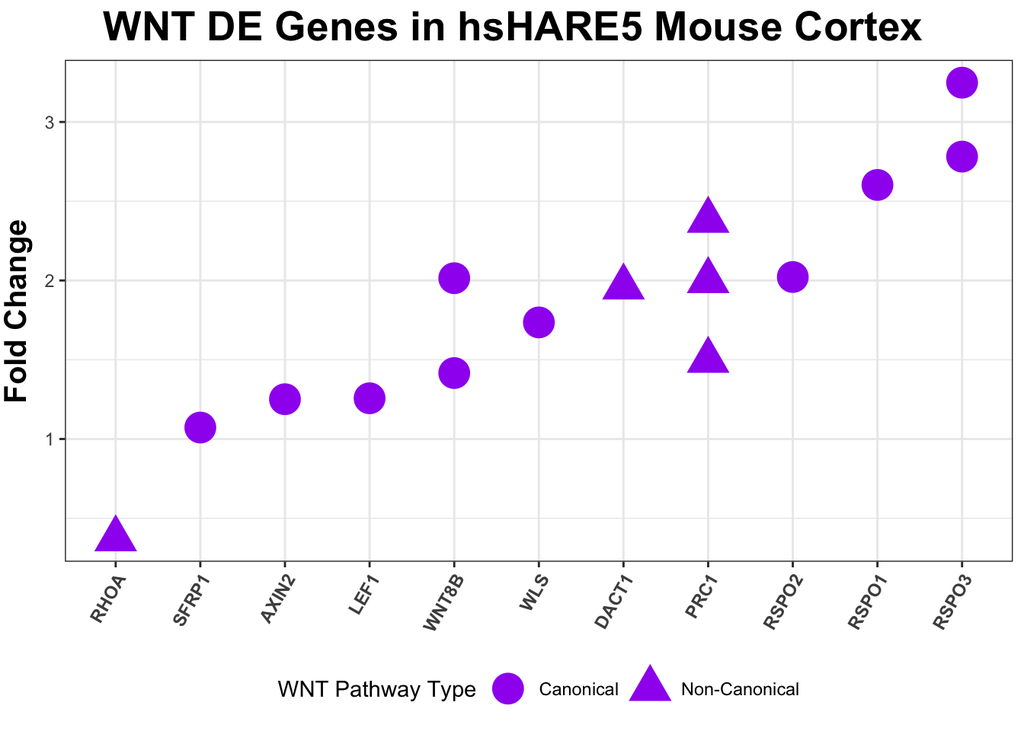

## Merging Datasets to Observe Differentially Expressed WNT Pathway Members that Interact with HARs

I used the `full_join()` function to merge the previously analyzed dataset of WNT genes differentally expressed in *hsHARE5* cortices and the WNT_HARs dataset

| Gene Name | Role in WNT Pathway | Fold Change | P Value | Adjusted P Value | Pathway | Enhancer |
| --- | --- | --- | --- | --- | --- | --- |
| SFRP1 | fzd-like receptor, modulator of Wnt signaling | 1.072174 | 0 | 0 | Canonical | HARsv2_2795 |
| PRC1 | positive feedback | 1.495564 | 0 | 0 | Non-Canonical | HARsv2_0936 |
| PRC1 | positive feedback | 1.998366 | 0 | 0 | Non-Canonical | HARsv2_0936 |
| PRC1 | positive feedback | 2.378706 | 0 | 0 | Non-Canonical | HARsv2_0936 |
| RSPO3 | regulator | 2.781500 | 0 | 0 | Canonical | HARsv2_2540 |
| RSPO3 | regulator | 3.247749 | 0 | 0 | Canonical | HARsv2_2540 |

## Visualizing Differentially Expressed WNT-HAR Genes Using `geom_col()`

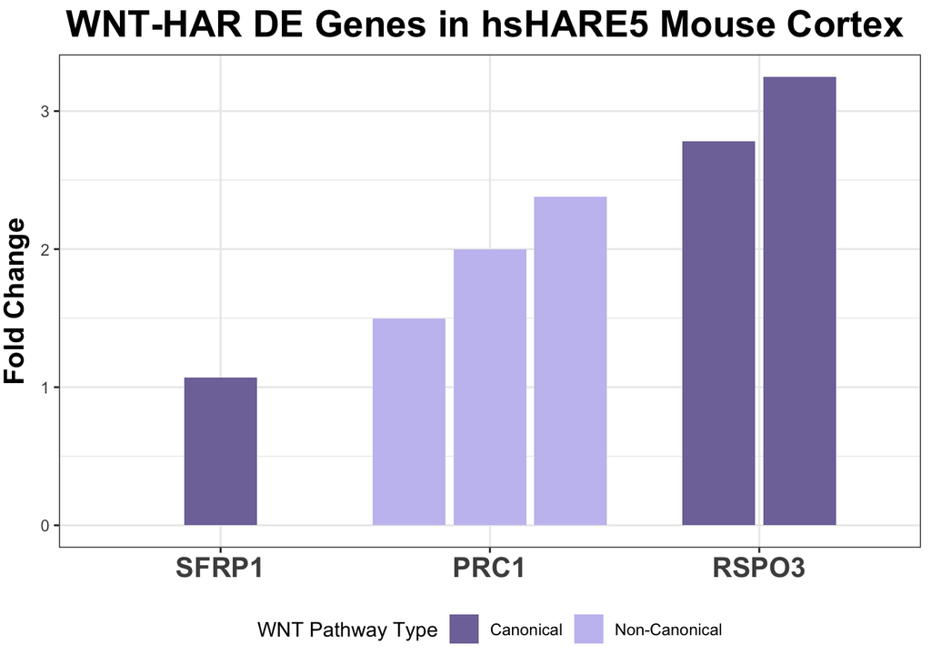

## Conclusions

In this project, I was able to observe that there are WNT Pathway genes that are differentially expressed in *hsHARE5* mouse corticies. However, only 3 of those are linked to other HAR regulation.

## Future Directions

I am interested in understanding how gene regulation of WNT pathway genes have co-evolved and worked synergistically. To continue with this study, I could do the follow

1. Examine the data to ensure gene name symbols were the same in all dataset to ensure no genes were left out of merging
2. Evaluate the raw data and not just the top 30 genes for each cluster
3. Look into WNT target gene change and not just WNT pathway gene
4. Manipulate the HARs associated with the WNT genes that are differentially regulated in the *hsHARE5* mouse cortex

## Acknowledgements

Thank you to **Dr. Matt Hirschey**, **Dr. Akshay Bareja**, and **Jess Portillo** for guidance in the Tidybiology class in learning to implement R and associated packages in my work. Thank you to **Dr. Jing Liu** for extending the data to conduct this project